# 03-runoff-susceptibility-map-blog

## **Rainfall to Risk:**

### **Mapping Surface Runoff Susceptibility in Nisqually River Watershed**

Climate change is expected to bring wetter winters to much of the Pacific Northwest, including Western WA, a place already characterized by its abundant winter rainfall. But does that mean surface runoff will shift on a map?

Not quite. In this analysis, projected increases in rain and snow during the wet winter season indicate that runoff susceptibility in the Nisqually River Watershed primarily intensifies in locations that are already moderately vulnerable, rather than creating entirely new high-risk areas. This suggests that landscape characteristics such as topography, soils, drainage, and land cover continue to hold a strong influence even under future climate conditions. Areas that were moderate-risk increase the most, and high-risk areas show a modest increase, important data for planning for aging infrastructure design, maintenance, and stormwater.

##### **Climate change doesn't always drastically shift runoff risk on a map, but it can definitely turn the volume up!**

Surface runoff, [defined as water that flows across the land surface](https://www.usgs.gov/water-science-school/science/surface-runoff-and-water-cycle), is a major driver of flooding and how it develops across the landscape. Rain leads to runoff, and excessive runoff leads to increased risk. Flooding is one of the most common natural disasters worldwide, causing billions of dollars in damages and threats to public safety. Meanwhile, climate change is only expected to increase the frequency and intensity of flood events.

Beyond flooding, increased surface runoff can contribute to:

- Increased soil erosion and landslides
- Reduced groundwater recharge
- Degraded water quality from pollutant transport
- Increased turbidity and drinking water treatment costs
- Flashier streams (water levels rising and falling rapidly during storm events)
- River channel instability
- Impacts on habitats and species, such as salmon

Flash floods are especially dangerous because they can develop quickly with little warning. As aging infrastructure and stormwater systems designed for historical conditions require maintenance and upgrades, communities are likely to become increasingly vulnerable to these impacts. With limited budgets and resources, data-driven approaches can help identify where investments will have the greatest impact and improve long-term climate resilience.

#### Study Area - Nisqually River Watershed, WA

The Nisqually Watershed in Washington, USA, was selected for this analysis due to its wide range of characteristics that influence surface runoff, making it a good candidate to explore surface runoff susceptibility spatially. The Nisqually River headwaters run from Mount Rainier, [an active volcano around 500,000 years old in its current form](https://www.usgs.gov/volcanoes/mount-rainier/science/geology-and-history-summary-mount-rainier), and originate from the Nisqually Glacier. It flows approximately 70 miles to Puget Sound, an inlet estuary of the Pacific Ocean. Its watershed covers 720 square miles and spans three counties: Thurston, Lewis, and Pierce, ending in several urban areas. The Nisqually runs through a large elevation range, from Mount Rainier at over 4,000 ft to sea level at the mouth of the river. The watershed is an interesting case study as it contains a variety of land covers, including mountain, forest, agriculture, and urban areas.

#### **Why do we need another tool for rainfall-runoff mapping? Why choose this model?**

Many methods and models have been developed to map rainfall-runoff. Topography is used in these models as it controls the movement of water across the landscape; soil type controls how quickly water flows into the ground, and land cover, such as impervious surface, changes runoff behavior due to the ground not being able to absorb the water.

This model and project were created to offer a watershed-scale first-pass screening tool to support decision-making and planning. Physically-based hydrologic models can be computationally expensive... hungry for time, resources, and data. This can make them hard to apply broadly, especially for screening-level analysis across organizations. This tool isn't a substitute for those detailed models. It helps determine high-risk areas and vulnerable communities when budgets, funding, and resources are tight, supporting targeted upgrades and maintenance to infrastructure, directing smaller localized studies, informing mitigation, or ensuring that climate projections are included in stormwater design. Additionally, this tool could be especially helpful for underserved, vulnerable, or at-risk communities that may lack the resources for detailed, site-specific hydrologic studies of their own.

Similar approaches are being developed because of this need. The Interstate Commission on the Potomac River Basin (ICPRB) developed an [interactive surface runoff map](https://www.potomacriver.org/news/new-interactive-map-to-identify-areas-vulnerable-to-stormwater-runoff/) and "susceptibility index" in February 2026 based on landscape characteristics. Their inputs included total watershed area, percent of watershed with underlying karst geology, average annual precipitation, soil characteristics, physiographic province, and average watershed slope. Similarly, they identified the need for mapping surface runoff susceptibility as a tool for decision-makers in planning, resource allocation, mitigation, and risk management.

There are trade-offs to be considered in a susceptibility-focused spatial model versus a fully simulated model. Fully simulated models have higher accuracy, finer resolution, and more physical realism (if done properly) to model flow volumes, flow timing, etc. However, these models are often impractical at the large-scale or screening-level analysis needed for planning and decision-making, as they require large, detailed datasets and calibration with observed data and expert oversight, which may not always be available.

This project builds off these ideas and approaches by using surface runoff landscape characteristics, including soils, topography, and land cover, and inputting them into a fuzzy logic model with average wet-season precipitation and one-day max rainfall as a proxy for storm intensity to create a surface runoff susceptibility map under historical and projected future climate conditions.

#### **Runoff Concentration + Runoff Generation = Runoff Susceptibility**

Where and how fast water flows through the landscape and where it pools and collects are both factors in overall surface runoff. To get a complete picture, the model was built using factors that represent both runoff concentration and generation.

Runoff concentration demonstrates how that water moves once it is on the landscape using slope and flow accumulation derived from a digital elevation model.

Runoff generation includes the characteristics that influence how much water becomes surface runoff in the first place… hydrologic soil groups, impervious surfaces, slope, average winter precipitation (December–February), and the maximum one-day precipitation (Rx1day) as a measure of storm intensity.

Fuzzy logic modeling was used as it allows for multiple variables to contribute at varying degrees to the overall model and allows for more flexibility than the binary logic of either/or susceptibility. In a geospatial fuzzy logic model, each pixel for each dataset is transformed to a common scale from 0 to 1, where higher values represent greater runoff susceptibility. This approach allows several moderate-risk conditions to combine and produce higher overall susceptibility, which better reflects how runoff behaves in the real world. Final surface runoff susceptibility was then calculated by combining runoff generation and runoff concentration into a single model.

#### **What's under the hood of the model...**

Topography: Slope and flow accumulation were derived from a Digital Elevation Model (DEM) using the `pysheds` Python [library](https://github.com/pysheds/pysheds). These variables represent how water naturally moves across the landscape.

Soils: Hydrologic soil groups converted to runoff susceptibility scores based on their infiltration capacity

Land cover: Percent impervious surface to represent development and surfaces that limit infiltration.

Climate: Mean winter precipitation (December–February) and Rx1day, the maximum one-day precipitation, which was used as a proxy for storm intensity.

Historical climate conditions (1976–2005) were compared with projected mid-century conditions (2041–2070) using the MACA climate dataset and the CCSM4 climate model. CCSM4 was selected because its projections are close to the ensemble mean for the watershed, making it a reasonable representation of expected future conditions. The mid-century period was chosen because it captures meaningful climate change while remaining relevant for current planning and infrastructure decisions. To explore shifts associated with climate change, the landscape itself remained unchanged between scenarios. The soils, drainage patterns, slope, and land-cover layers were held constant, while only the climate variables were replaced with future precipitation and storm intensity projections.

This made it possible to uncover an answer to the question:

#### **What does the surface runoff susceptibility look like currently? And do we see any changes spatially due to climate change projections?**

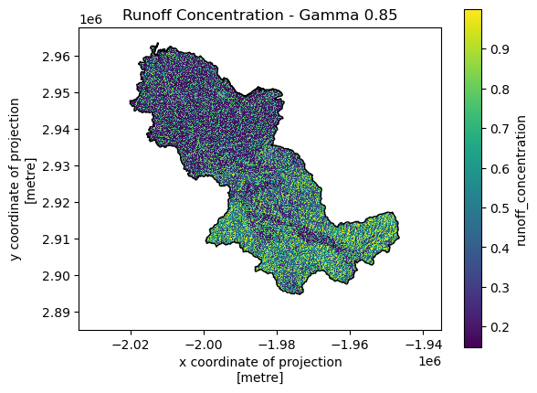

#### Figure 2: This map shows runoff concentration across the Nisqually watershed, calculated from slope and flow accumulation, a measure of how quickly water moving across the landscape converges toward stream channels or the drainage networks. Brighter (yellow) areas indicate higher concentration potential, while darker (purple) areas indicate lower concentration. This forms one of the key inputs to the susceptibility model.

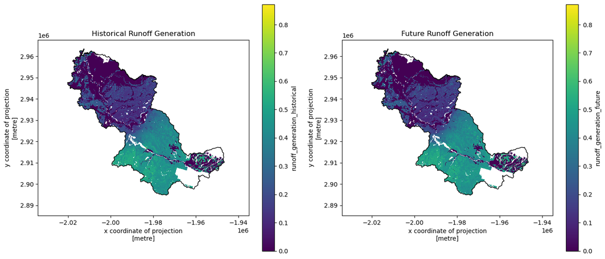

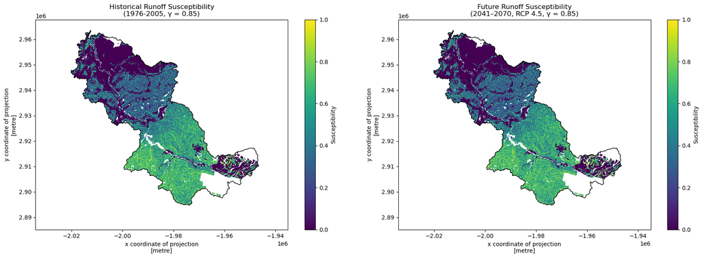

#### Figure 4: These maps show the final susceptibility maps, combining runoff concentration and runoff generation into a single score using a fuzzy logic model. A gamma operator, an algebraic formula that blends fuzzy product and fuzzy sum logic, was used to combine the two inputs, allowing for a nuanced 0–1 susceptibility score rather than a simple yes/no threshold. We see the highest susceptibility in the south-central part of the watershed and moderate susceptibility in the north-central and northwest region towards the mouth of the river. The low susceptibility in parts of the watershed stayed remarkably low across different gamma values tested, likely linked to naturally high-infiltration soils in that area. The two time periods look broadly similar at a glance, with modest increases in parts of the watershed under future conditions.

## **In fact, 69% of valid pixels in the watershed showed some change under future climate conditions, and 93% of that change was an increase - reinforcing that climate change is more likely to intensify existing risk than create entirely new hotspots.**

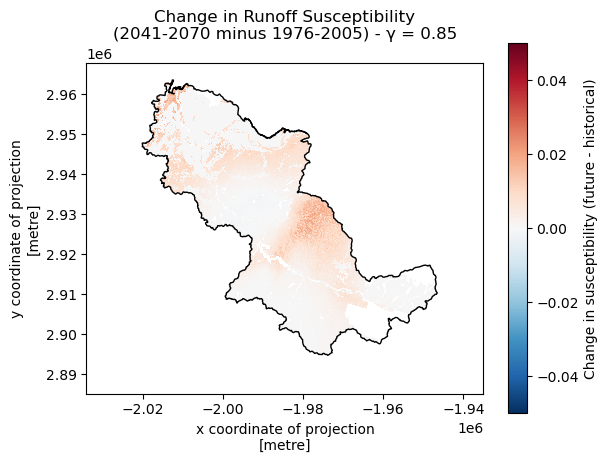

#### Figure 5: This map shows the change in runoff susceptibility between mid-century predictions and current/historical conditions. Although the changes are modest, around 0.01–0.04, most are increases: 69% of valid pixels in the watershed showed some change, and 93% of those changes were increases. The largest changes are concentrated in the central-eastern part of the watershed, an area that already shows moderate susceptibility. This matters for stormwater planning - it's a signal that infrastructure here should be checked for capacity to handle increased runoff or do smaller localized studies with physical data collection, and that maintenance or upgrades could be prioritized in this area first.

Next steps for building on this analysis and model could include incorporating machine learning validation with hydrological data, exploring other climate scenarios like RCP 8.5 or models beyond the mean, or applying it to another watershed.

### Interested in learning more? Curious about the code?

[Check out the code!](https://nym-veach.github.io/portfolio_posts/01-runoff-fuzzy-logic-model.html)

[Check out the repo here](https://github.com/nym-veach/surface-runoff-susceptibility-model)

Data Citations

- Abatzoglou, J. T., & Brown, T. J. (2012). A comparison of statistical downscaling methods suited for wildfire applications. International Journal of Climatology, 32(5), 772–780. https://doi.org/10.1002/joc.2313
- NASA Jet Propulsion Laboratory (JPL). (2013). NASA Shuttle Radar Topography Mission Global 1 arc second [Data set]. NASA Land Processes Distributed Active Archive Center. https://doi.org/10.5067/MEASURES/SRTM/SRTMGL1.003
- Soil Survey Staff. Gridded Soil Survey Geographic (gSSURGO) Database for Washington. United States Department of Agriculture, Natural Resources Conservation Service. Available online at https://gdg.sc.egov.usda.gov/. Accessed April 7, 2026.
- U.S. Geological Survey (USGS), 2024, Annual NLCD Collection 1 Science Products: U.S. Geological Survey data release, https://doi.org/10.5066/P94UXNTS
- U.S. Geological Survey. Watershed Boundary Dataset (WBD), 8-digit Hydrologic Unit Code 17110015 — Nisqually. National Geospatial Technical Operations Center, 2025.

*Disclaimer: This post reflects independent academic work completed as part of my graduate capstone at CU Boulder. It was not conducted on behalf of, and does not represent the views of, my employer.*